# Analysis of the climatic events that impacts health and economy of the EUA.

Marco Pollo Almeida

2/11/2020

## 1. Outline

This project involves exploring the U.S. National Oceanic and Atmospheric Administration’s (NOAA) storm database. Storms and other severe weather events can cause both public health and economic problems for communities and municipalities. To prevent such outcomes to the extent possible is a key concern. The dataset presents the 1950 to 2011 period.

Based on the documentation of the dataset [here](https://d396qusza40orc.cloudfront.net/repdata%2Fpeer2_doc%2Fpd01016005curr.pdf), one investigates the main events which cause harm to Health (injuries and fatalities) and Economic Field (properties and crops).

## 2. Data Processing

### 2.1. Data Loading

Following steps: Downloading the dataset (raw data). Extract it from bzip2 file. Read and convert it into a “data.table” object.

```r
# Load packages that will be used
library(data.table)
library(tidyverse)
```

```r
# Download and extract the file
URL <- "https://d396qusza40orc.cloudfront.net/repdata%2Fdata%2FStormData.csv.bz2"
download.file(URL, destfile = paste0("~/", '/repdata%2Fdata%2FStormData.csv.bz2'))

# read the data
dt <- read.csv("~/repdata%2Fdata%2FStormData.csv.bz2")

# Transform to "data.table" object
dt <- as.data.table(dt)
```

### 2.2. Inspecting variables (name, type, class, etc.)

```r
str(dt)
```

```
## Classes 'data.table' and 'data.frame':   902297 obs. of  37 variables:
##  $ STATE__   : num  1 1 1 1 1 1 1 1 1 1 ...
##  $ BGN_DATE  : Factor w/ 16335 levels "1/1/1966 0:00:00",..: 6523 6523 4242 11116 2224 2224 2260 383 3980 3980 ...
##  $ BGN_TIME  : Factor w/ 3608 levels "00:00:00 AM",..: 272 287 2705 1683 2584 3186 242 1683 3186 3186 ...
##  $ TIME_ZONE : Factor w/ 22 levels "ADT","AKS","AST",..: 7 7 7 7 7 7 7 7 7 7 ...
##  $ COUNTY    : num  97 3 57 89 43 77 9 123 125 57 ...
##  $ COUNTYNAME: Factor w/ 29601 levels "","5NM E OF MACKINAC BRIDGE TO PRESQUE ISLE LT MI",..: 13513 1873 4598 10592 4372 10094 1973 23873 24418 4598 ...
##  $ STATE     : Factor w/ 72 levels "AK","AL","AM",..: 2 2 2 2 2 2 2 2 2 2 ...
##  $ EVTYPE    : Factor w/ 985 levels "   HIGH SURF ADVISORY",..: 834 834 834 834 834 834 834 834 834 834 ...
##  $ BGN_RANGE : num  0 0 0 0 0 0 0 0 0 0 ...
##  $ BGN_AZI   : Factor w/ 35 levels "","  N"," NW",..: 1 1 1 1 1 1 1 1 1 1 ...
##  $ BGN_LOCATI: Factor w/ 54429 levels ""," Christiansburg",..: 1 1 1 1 1 1 1 1 1 1 ...
##  $ END_DATE  : Factor w/ 6663 levels "","1/1/1993 0:00:00",..: 1 1 1 1 1 1 1 1 1 1 ...
##  $ END_TIME  : Factor w/ 3647 levels ""," 0900CST",..: 1 1 1 1 1 1 1 1 1 1 ...
##  $ COUNTY_END: num  0 0 0 0 0 0 0 0 0 0 ...
```

[output cut: 24 more lines]

### 2.3. Create new dataset from the raw data (subsetting).

Create new dataset based on the requirements of the project.

```r
# Variables to remove
rmVarb <- colnames(dt[, !c("EVTYPE", "FATALITIES", "INJURIES", "PROPDMG", "PROPDMGEXP", "CROPDMG", "CROPDMGEXP")])

# Removing variables
dt[, c(rmVarb) := NULL]

# Filtering data only with fatalities or injuries
dt <- dt[(EVTYPE != "?" & (INJURIES > 0 | FATALITIES > 0 | PROPDMG > 0 | CROPDMG > 0)), c("EVTYPE", "FATALITIES", "INJURIES", "PROPDMG", "PROPDMGEXP", "CROPDMG", "CROPDMGEXP") ]
```

### 2.4. Transforming some characters according to documentation, in order to make possible the calculations.

Clean the PROPDMGEXP and CROPDMGEXP variables in order to calculate some results related to cost crop and properties.

```r
# Change some characters to uppercase.
cols <- c("PROPDMGEXP", "CROPDMGEXP")
dt[,  (cols) := c(lapply(.SD, toupper)), .SDcols = cols]
# Change alphanumeric exponents to numeric values (for PROPERTY variable).
propDmgKey <-  c("\"\"" = 10^0,
                 "-" = 10^0,
                 "+" = 10^0,
                 "0" = 10^0,
                 "1" = 10^1,
                 "2" = 10^2,
                 "3" = 10^3,
                 "4" = 10^4,
                 "5" = 10^5,
                 "6" = 10^6,
                 "7" = 10^7,
                 "8" = 10^8,
                 "9" = 10^9,
                 "H" = 10^2,
                 "K" = 10^3,
                 "M" = 10^6,
                 "B" = 10^9)
# Change alphanumeric exponents to numeric values.
cropDmgKey <-  c("\"\"" = 10^0,
                "?" = 10^0,
                "0" = 10^0,
                "K" = 10^3,
                "M" = 10^6,
                "B" = 10^9)
dt[, PROPDMGEXP := propDmgKey[as.character(dt[,PROPDMGEXP])]]
dt[is.na(PROPDMGEXP), PROPDMGEXP := 10^0 ]
dt[, CROPDMGEXP := cropDmgKey[as.character(dt[,CROPDMGEXP])] ]
dt[is.na(CROPDMGEXP), CROPDMGEXP := 10^0 ]
```

### 2.5. Creating Economic Cost Variables

```r
dt <- dt[, .(EVTYPE, FATALITIES, INJURIES, PROPDMG, PROPDMGEXP, propCost = PROPDMG * PROPDMGEXP, CROPDMG, CROPDMGEXP, cropCost = CROPDMG * CROPDMGEXP)]
```

### 2.6. Creating Total Property and Crop Cost Variables

```r
dt2 <- dt[, .(propCost = sum(propCost), cropCost = sum(cropCost), Total_Cost = sum(propCost) + sum(cropCost)), by = .(EVTYPE)]
dt2 <- dt2[order(-Total_Cost), ]
dt2 <- dt2[1:10, ]
head(dt2, 5)
```

```
##               EVTYPE     propCost   cropCost   Total_Cost
## 1:             FLOOD 144657709807 5661968450 150319678257
## 2: HURRICANE/TYPHOON  69305840000 2607872800  71913712800
## 3:           TORNADO  56947380676  414953270  57362333946
## 4:       STORM SURGE  43323536000       5000  43323541000
## 5:              HAIL  15735267513 3025954473  18761221986
```

### 2.7. Creating Total Fatalities and Injuries Variables

```r
dt3 <- dt[, .(FATALITIES = sum(FATALITIES), INJURIES = sum(INJURIES), totals = sum(FATALITIES) + sum(INJURIES)), by = .(EVTYPE)]
dt3 <- dt3[order(-FATALITIES), ]
dt3 <- dt3[1:10, ]
head(dt3, 5)
```

```
##            EVTYPE FATALITIES INJURIES totals
## 1:        TORNADO       5633    91346  96979
## 2: EXCESSIVE HEAT       1903     6525   8428
## 3:    FLASH FLOOD        978     1777   2755
## 4:           HEAT        937     2100   3037
## 5:      LIGHTNING        816     5230   6046
```

## 3. Results

### 3.1. Events that are Most Harmful to Population Health

Melting data.table so that it is easier to put in bar graph format

```r
dt4 <- melt(dt3, id.vars="EVTYPE", variable.name = "bad_thing")
head(dt4, 5)
```

```
##            EVTYPE  bad_thing value
## 1:        TORNADO FATALITIES  5633
## 2: EXCESSIVE HEAT FATALITIES  1903
## 3:    FLASH FLOOD FATALITIES   978
## 4:           HEAT FATALITIES   937
## 5:      LIGHTNING FATALITIES   816
```

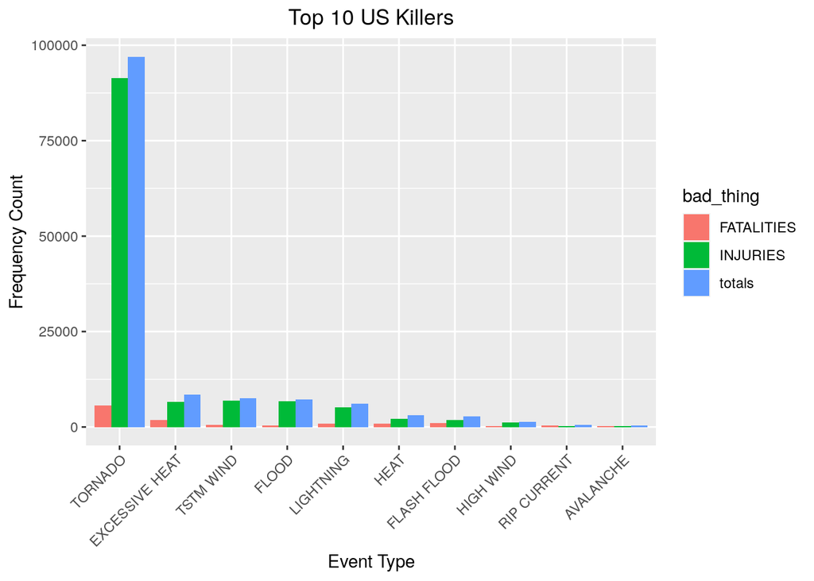

```r
# Create chart
healthChart <- ggplot(dt4, aes(x=reorder(EVTYPE, -value), y=value))
# Plot data as bar chart
healthChart = healthChart + geom_bar(stat="identity", aes(fill=bad_thing), position="dodge")
# Format y-axis scale and set y-axis label
healthChart = healthChart + ylab("Frequency Count")
# Set x-axis label
healthChart = healthChart + xlab("Event Type")
# Rotate x-axis tick labels
healthChart = healthChart + theme(axis.text.x = element_text(angle=45, hjust=1))
# Set chart title and center it
healthChart = healthChart + ggtitle("Top 10 US Killers") + theme(plot.title = element_text(hjust = 0.5))
healthChart
```

### 3.2. Events that have the Greatest Economic Consequences

Melting data.table so that it is easier to put in bar graph format

```r
dt5 <- melt(dt2, id.vars="EVTYPE", variable.name = "Damage_Type")
head(dt5, 5)
```

```
##               EVTYPE Damage_Type        value
## 1:             FLOOD    propCost 144657709807
## 2: HURRICANE/TYPHOON    propCost  69305840000
## 3:           TORNADO    propCost  56947380676
## 4:       STORM SURGE    propCost  43323536000
## 5:              HAIL    propCost  15735267513
```

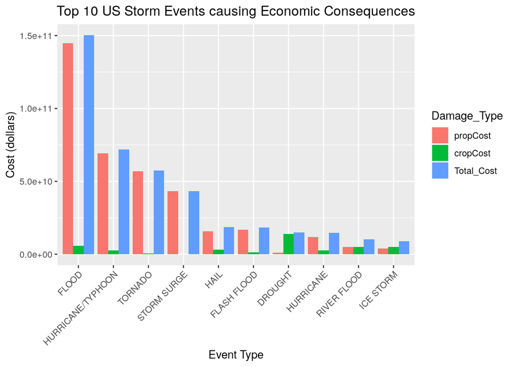

```r
# Create chart
econChart <- ggplot(dt5, aes(x=reorder(EVTYPE, -value), y=value))
# Plot data as bar chart
econChart = econChart + geom_bar(stat="identity", aes(fill=Damage_Type), position="dodge")
# Format y-axis scale and set y-axis label
econChart = econChart + ylab("Cost (dollars)")
# Set x-axis label
econChart = econChart + xlab("Event Type")
# Rotate x-axis tick labels
econChart = econChart + theme(axis.text.x = element_text(angle=45, hjust=1))
# Set chart title and center it
econChart = econChart + ggtitle("Top 10 US Storm Events causing Economic Consequences") + theme(plot.title = element_text(hjust = 0.5))
econChart
```